# Fish Welfare Initiative Data Review

## Objective

Review data quality and data trends to gain insights into M&E campaign

## **Dataset**

The dataset contains the following features:

- JotForm Entry ID : JotForm Entry ID : int
- Observer ID : Observer ID : int
- Date : Date : date
- Pond ID : Pond ID : Alpha numeric
- Morning or Evening : Type of Measurement : Descriptive
- Time : Time : Military time
- Meter : Meter : Descriptive
- Follow up Measurement? : Follow up Measurement? : Yes, No
- DO (mg/L) : Dissolved Oxygen (DO) average in mg/L : float
- Temp (C) : Temperature average in Celsius : float
- pH : pH average : float
- Ammonia (mg/L) : Ammonia average in mg/L : float
- Turbidity (cm) : Turbidity average in cm (via Secchi disk) : float
- Salinity (ppt) : Salinity in ppt : float
- TDS (ppt) : Total Dissolved Solids in ppt : float
- Sun : Weather : Sun : Descriptive
- Clouds : Weather : Clouds : Descriptive
- Rain : Weather : Rain : Descriptive
- Wind : Wind : Descriptive
- Quality in range? : Is water quality in the required range? : Yes, No
- Parameter(s) OOR : Which parameter(s) is/are out of range? : Descriptive
- CA Requested : Farmer : Corrective actions requested from the farmer : Descriptive
- CA Taken? : Farmer : Did the farmer implement the corrective actions? : Yes, No
- Correct CA Taken? : Farmer : Did the farmer implement the corrective actions for achieving ideal ranges? : Yes, No
- CA Actual : Farmer : Corrective actions taken by the farmer : Descriptive
- CA Difficulty : Farmer : How did the farmer find implementing the corrective actions? : Descriptive
- Post CA improvement? : Did the targeted water quality parameters improve to the required range after the implementation of corrective actions? : Yes, No
- Reason for inaction : Farmer : If the farmer didn't apply corrective actions what were the reasons? : Descriptive
- Stocking Density (fish/acre) : Stocking density per acre : int
- Daily feed (kg) : How much feed does the farmer give per day in kg? : float
- Disease outbreak? : Is this pond currently experiencing a disease outbreak? : Yes, No
- Lice infestation? : Is this pond currently having a lice infestation? : Yes, No
- Feeding behavior : Feeding : int
- Air gulping extent : Air gulping : int
- Tail splashing extent : Tail splashing : int
- Farmer dead fish (15 day count) : How many dead fish did the FARMER find in the last 15 days? : int
- FWI dead fish count : How many dead fish did FWI find during their visit? : int
- FWI impact noted : Did we help the fish at this pond per our definition? : Yes, No
- Description of impact : How did we help the fish? : Descriptive
- How many fish did we help? : How many fish did we help? : Int
- Primary Productivity GPP (mg/L) : Primary Productivity GPP in mg/L : float
- Light bottle DO NPP : Light bottle DO NPP : float
- Dark bottle DO R : Dark bottle DO R : float
- Water color : Water Color : Descriptive
- PP (mg/L) : PP in mg/L : float
- Pond locations visited : How many locations will you visit at this pond? : int
- T1 (C) : Reader 1 : Temperature in Celsius : float
- DO1 (mg/L) : Reader 1 : Dissolved Oxygen in mg/L : float
- pH1 : Reader 1 : pH : float
- T2 (C) : Reader 2 : Temperature in Celsius : float
- DO2 (mg/L) : Reader 2 -Dissolved Oxygen in mg/L : float
- pH2 : Reader 2 : pH : float
- T3 (C) : Reader 3 : Temperature in Celsius : float
- DO3 (mg/L) : Reader 3 : Dissolved Oxygen in mg/L : float
- pH3 : Reader 3 : pH : float
- Notes : 1 : Notes : 1 : Descriptive
- Notes : 2 : Notes : 2 : Descriptive
- Notes : 3 : Notes : 3 : Descriptive
- Notes : 4 : Notes : 4 : Descriptive
- Notes : 5 : Notes : 5 : Descriptive
- Submission Date : Submission Date : Date

## **Importing libraries and overview of the dataset**

```python
import pandas as pd
import warnings
import numpy as np
import matplotlib.pyplot as plt
import seaborn as sns
sns.set(style="whitegrid")
# To scale the data using z-score
from sklearn.preprocessing import StandardScaler
# Importing PCA and t-SNE
from sklearn.decomposition import PCA
from sklearn.manifold import TSNE
warnings.filterwarnings("ignore")
import datetime

!pip install pyspark
import pyspark.sql.functions as F
```

## **Loading data**

```python
# loading the dataset
df = pd.read_csv("FWI_data_v0.csv", parse_dates=['Date','Submission Date']);
df.set_index(['Pond ID','Date', 'Morning or Evening' ])
```

| Pond ID | Date | Morning or Evening | Jotform Entry ID | Observer ID | Time | Meter | Follow up Measurement? | DO (mg/L) | Temp (C) | pH | Ammonia (mg/L) | Turbidity (cm) | ... | pH2 | T3 (C) | DO3 (mg/L) | pH3 | Notes - 1 | Notes - 2 | Notes - 3 | Notes - 4 | Notes - 5 | Submission Date |
| --- | --- | --- | --- | --- | --- | --- | --- | --- | --- | --- | --- | --- | --- | --- | --- | --- | --- | --- | --- | --- | --- | --- | --- |
| 1-T-47-1 | 2021-06-19 | Evening | 2213 | NaN | NaN | NaN | NaN | NaN | 32.20 | NaN | NaN | NaN | ... | NaN | NaN | NaN | NaN | NaN | NaN | NaN | NaN | NaN | NaT |
|  |  | Morning | 2214 | NaN | NaN | NaN | NaN | NaN | 29.50 | NaN | NaN | NaN | ... | NaN | NaN | NaN | NaN | NaN | NaN | NaN | NaN | NaN | NaT |
|  | 2021-07-04 | Evening | 2240 | NaN | 17:30 | NaN | NaN | NaN | 31.80 | NaN | NaN | 29.1 | ... | NaN | NaN | NaN | NaN | NaN | NaN | NaN | NaN | NaN | NaT |
|  |  | Morning | 2241 | NaN | 8:20 | NaN | NaN | NaN | 31.20 | NaN | NaN | 28.8 | ... | NaN | NaN | NaN | NaN | NaN | NaN | NaN | NaN | NaN | NaT |
| 1-T-34-1 | 2021-07-06 | Evening | 2242 | NaN | NaN | NaN | NaN | NaN | NaN | NaN | NaN | NaN | ... | NaN | NaN | NaN | NaN | NaN | NaN | NaN | NaN | NaN | NaT |
| ... | ... | ... | ... | ... | ... | ... | ... | ... | ... | ... | ... | ... | ... | ... | ... | ... | ... | ... | ... | ... | ... | ... | ... |
| 2-T-17-1 | 2022-09-22 | Evening | 2 | 4.0 | 16:55 | Han | No | 8.47 | 30.16 | 8.75 | NaN | 24.0 | ... | 8.77 | NaN | NaN | NaN | NaN | NaN | NaN | NaN | NaN | 2022-09-22 |
| 2-C-51-1 | 2022-09-22 | Morning | 3 | 4.0 | 7:53 | Han | No | 2.96 | 29.60 | 8.35 | NaN | 25.0 | ... | 8.35 | NaN | NaN | NaN | NaN | NaN | NaN | NaN | NaN | 2022-09-22 |
|  |  | Evening | 4 | 4.0 | 17:04 | Han | No | 3.90 | 30.02 | 8.38 | NaN | 25.0 | ... | 8.37 | NaN | NaN | NaN | NaN | NaN | NaN | NaN | NaN | 2022-09-22 |
| 2-C-51-2 | 2022-09-22 | Morning | 5 | 4.0 | 8:03 | Han | No | 3.46 | 29.56 | 8.43 | NaN | 25.0 | ... | 8.43 | NaN | NaN | NaN | NaN | NaN | NaN | NaN | NaN | 2022-09-22 |
|  |  | Evening | 6 | 4.0 | 17:15 | Han | No | 7.74 | 30.34 | 8.61 | NaN | 25.0 | ... | 8.61 | NaN | NaN | NaN | NaN | NaN | NaN | NaN | NaN | 2022-09-22 |

2434 rows × 58 columns

```python
pd.set_option('display.max_columns', None)
df.head(5)
```

|  | Jotform Entry ID | Observer ID | Date | Pond ID | Morning or Evening | Time | Meter | Follow up Measurement? | DO (mg/L) | Temp (C) | pH | Ammonia (mg/L) | Turbidity (cm) | Salinity (ppt) | TDS (ppt) | Sun | Clouds | Rain | Wind | Quality in range? | Parameter(s) OOR | CA Requested - Farmer | CA Taken? - Farmer | Correct CA Taken? - Farmer | CA Actual - Farmer | CA Difficulty - Farmer | Post CA improvement? | Reason for inaction - Farmer | Stocking Density (fish/acre) | … |
| --- | --- | --- | --- | --- | --- | --- | --- | --- | --- | --- | --- | --- | --- | --- | --- | --- | --- | --- | --- | --- | --- | --- | --- | --- | --- | --- | --- | --- | --- | --- |
| 0 | 2213 | NaN | 2021-06-19 | 1-T-47-1 | Evening | NaN | NaN | NaN | NaN | 32.2 | NaN | NaN | NaN | NaN | NaN | NaN | NaN | No rain | NaN | NaN | NaN | NaN | NaN | NaN | NaN | NaN | NaN | NaN | NaN | … |
| 1 | 2214 | NaN | 2021-06-19 | 1-T-47-1 | Morning | NaN | NaN | NaN | NaN | 29.5 | NaN | NaN | NaN | NaN | NaN | NaN | NaN | No rain | NaN | NaN | NaN | NaN | NaN | NaN | NaN | NaN | NaN | NaN | NaN | … |
| 2 | 2240 | NaN | 2021-07-04 | 1-T-47-1 | Evening | 17:30 | NaN | NaN | NaN | 31.8 | NaN | NaN | 29.1 | NaN | NaN | NaN | NaN | No rain | NaN | NaN | NaN | NaN | NaN | NaN | NaN | NaN | NaN | NaN | NaN | … |
| 3 | 2241 | NaN | 2021-07-04 | 1-T-47-1 | Morning | 8:20 | NaN | NaN | NaN | 31.2 | NaN | NaN | 28.8 | NaN | NaN | NaN | NaN | No rain | NaN | NaN | NaN | NaN | NaN | NaN | NaN | NaN | NaN | NaN | NaN | … |
| 4 | 2242 | NaN | 2021-07-06 | 1-T-34-1 | Evening | NaN | NaN | NaN | NaN | NaN | NaN | NaN | NaN | NaN | NaN | NaN | NaN | No rain | NaN | NaN | NaN | NaN | NaN | NaN | NaN | NaN | NaN | NaN | NaN | … |

```python
df.info()
```

```
<class 'pandas.core.frame.DataFrame'>
RangeIndex: 2434 entries, 0 to 2433
Data columns (total 61 columns):
 #   Column                           Non-Null Count  Dtype
---  ------                           --------------  -----
 0   Jotform Entry ID                 2434 non-null   int64
 1   Observer ID                      2057 non-null   float64
 2   Date                             2434 non-null   datetime64[ns]
 3   Pond ID                          2433 non-null   object
 4   Morning or Evening               2434 non-null   object
 5   Time                             2418 non-null   object
 6   Meter                            2021 non-null   object
 7   Follow up Measurement?           2057 non-null   object
 8   DO (mg/L)                        2329 non-null   float64
 9   Temp (C)                         2429 non-null   float64
```

[output cut: 53 more lines]

```python
# Print the shape of the data
df.describe().T
```

|  | count | mean | std | min | 25% | 50% | 75% | max |
| --- | --- | --- | --- | --- | --- | --- | --- | --- |
| Jotform Entry ID | 2434.0 | 1217.500000 | 702.779600 | 1.00 | 609.25 | 1217.500 | 1825.7500 | 2434.00 |
| Observer ID | 2057.0 | 2.591152 | 1.880315 | 1.00 | 1.00 | 1.000 | 5.0000 | 6.00 |
| DO (mg/L) | 2329.0 | 6.257050 | 3.314439 | 0.20 | 3.53 | 4.780 | 8.9100 | 21.05 |
| Temp (C) | 2429.0 | 29.913285 | 2.099176 | 23.40 | 28.44 | 30.050 | 31.4000 | 35.60 |
| pH | 2331.0 | 8.131090 | 0.373692 | 3.38 | 7.91 | 8.150 | 8.3700 | 9.54 |
| Ammonia (mg/L) | 1455.0 | 0.097227 | 0.230910 | 0.00 | 0.00 | 0.010 | 0.0500 | 2.02 |
| Turbidity (cm) | 2149.0 | 28.731643 | 9.705860 | 9.00 | 23.00 | 28.000 | 32.0000 | 89.00 |
| Salinity (ppt) | 1663.0 | 1.299958 | 0.688197 | 0.02 | 0.89 | 1.100 | 1.5100 | 4.20 |
| TDS (ppt) | 1684.0 | 1.312277 | 0.844706 | 0.01 | 0.79 | 1.075 | 1.4800 | 6.20 |
| Stocking Density (fish/acre) | 1087.0 | 2796.444342 | 1758.810500 | 0.00 | 2000.00 | 2630.000 | 3500.0000 | 31666.00 |
| Daily feed (kg) | 1583.0 | 328.393557 | 1364.302347 | 0.00 | 40.00 | 100.000 | 300.0000 | 28050.00 |
| Feeding behaviour | 399.0 | 0.055138 | 0.342863 | 0.00 | 0.00 | 0.000 | 0.0000 | 3.00 |
| Air gulping extent | 1133.0 | 0.065313 | 0.496602 | 0.00 | 0.00 | 0.000 | 0.0000 | 6.00 |
| Tail splashing extent | 1133.0 | 0.165931 | 0.506848 | 0.00 | 0.00 | 0.000 | 0.0000 | 3.00 |
| Farmer dead fish (15 day count) | 2432.0 | 0.290296 | 4.846855 | 0.00 | 0.00 | 0.000 | 0.0000 | 130.00 |
| FWI dead fish count | 2432.0 | 0.053043 | 0.860524 | 0.00 | 0.00 | 0.000 | 0.0000 | 30.00 |
| How many fish did we help? | 40.0 | 16408.850000 | 17182.350950 | 1500.00 | 7375.00 | 12000.000 | 18000.0000 | 77004.00 |
| Primary Productivity GPP (mg/L) | 958.0 | 2.135209 | 1.636157 | 0.00 | 0.00 | 2.400 | 3.2000 | 11.30 |
| Light bottle DO NPP | 697.0 | 4.756198 | 1.533356 | 1.20 | 3.90 | 4.800 | 5.7000 | 13.10 |
| Dark bottle DO R | 697.0 | 1.823902 | 0.748265 | 0.23 | 1.28 | 1.800 | 2.2800 | 5.19 |
| PP (mg/L) | 233.0 | 6.278240 | 2.533828 | 0.20 | 4.67 | 6.100 | 8.0000 | 15.20 |
| Pond locations visited | 2055.0 | 2.005353 | 0.317412 | 1.00 | 2.00 | 2.000 | 2.0000 | 3.00 |
| T1 (C) | 1957.0 | 29.848661 | 2.130433 | 23.43 | 28.27 | 29.900 | 31.4000 | 35.70 |
| DO1 (mg/L) | 2057.0 | 6.372210 | 3.300457 | 0.10 | 3.63 | 4.900 | 9.0000 | 24.50 |
| pH1 | 2057.0 | 8.116130 | 0.430068 | 0.00 | 7.90 | 8.140 | 8.3700 | 11.07 |
| T2 (C) | 2057.0 | 29.781895 | 2.271635 | 3.64 | 28.20 | 29.900 | 31.4000 | 35.50 |
| DO2 (mg/L) | 1958.0 | 6.324780 | 3.310094 | 0.08 | 3.57 | 4.820 | 8.9975 | 20.70 |
| pH2 | 1959.0 | 8.143874 | 0.349105 | 5.45 | 7.93 | 8.170 | 8.3800 | 9.29 |
| T3 (C) | 109.0 | 29.861009 | 2.140997 | 25.10 | 28.50 | 30.100 | 31.4000 | 34.10 |
| DO3 (mg/L) | 109.0 | 6.966789 | 3.813312 | 0.20 | 3.90 | 4.800 | 9.9000 | 16.70 |
| pH3 | 109.0 | 8.179450 | 0.404667 | 6.76 | 7.96 | 8.140 | 8.3800 | 9.28 |

```python
# Review unique results from Quality in range?
df['Quality in range?'].value_counts()
```

```
Yes    1577
No      477
Name: Quality in range?, dtype: int64
```

```python
# Set Quality In Range as a binary integer
df["QIR"] = df["Quality in range?"].replace({"Yes": 1, "No": 0})
df['QIR'].value_counts()
```

```
1.0    1577
0.0     477
Name: QIR, dtype: int64
```

```python
# count unique values of corrective actions
df['CA Actual - Farmer'].value_counts()
```

```
Water exchange                                                               65
Water exchange\nStop feeding for 48 hours                                    11
Water exchange\nZeolite\nStop feeding for 48 hours                           10
Turning aerators on for 1 day                                                 9
Water exchange\nZeolite                                                       9
Water exchange\nAdded Jaggery                                                 7
Water exchange\nAdded Alum                                                    7
Water exchange\nProbiotic\nAdded Jaggery                                      6
Water exchange\nTurning aerators on for 1 day                                 6
Water exchange\nTurning aerators on for 2 days                                4
Water exchange\nZeolite\ngypum add fertillization                             4
Water exchange\nAdded Jaggery as a probiotic                                  3
Water exchange\nAddd Jaggery 5kg per acre                                     3
Water exchange\nProbiotic                                                     3
Water exchange\nStopped feeding for 24 hours                                  2
Water exchange\nADDED CRACKED CORN AND GYPSUM TO REDUCE pH                    2
Zeolite                                                                       2
Water exchange\nZeolite\ngypum                                                2
Water exchange\nTurning aerators on for 2 days\nStop feeding for 48 hours     2
Added jaggery powder to the pond                                              2
Turning aerators on for 1 day\nStop feeding for 48 hours                      2
Water exchange\nProbiotic\nAdded Alum                                         2
Water exchange\nTurning aerators on for 2 days\nGodrej DE-AM for Ammonia      2
Water exchange\nAdded Jaggery 5kg per acre                                    1
None                                                                          1
Water exchange\nZeolite\nAdd Jaggery                                          1
Water exchange\nGodrej DE-AM to reduce ammonia                                1
Water exchange\ngypum                                                         1
Zeolite\ngypum add fertillization                                             1
Turning aerators on for 2 days                                                1
Water exchange\nProbiotic\nAdd Jaggery                                        1
DE-AM                                                                         1
Water exchange\nZeolite\nAdded Jaggery                                        1
Water exchange\nProbiotic\nAdded Jaggery and Probiotics                       1
Applied jaggery powder into the pond                                          1
Name: CA Actual - Farmer, dtype: int64
```

```python
# Assign Corrective Action column as a binary integer

df["CA"] = 0
df["CA"][df["CA Actual - Farmer"].notnull()] = 1
df['CA'].value_counts()
```

```
0    2257
1     177
Name: CA, dtype: int64
```

```python
# How many ponds are control ponds?
df['Pond ID'].str.contains('C').value_counts()
```

```
False    2118
True      315
Name: Pond ID, dtype: int64
```

```python
# Assign a control_pond column = 1 for control ponds
df["control_pond"] = 0
df["control_pond"][df["Pond ID"].astype(str).str.contains('C')] = 1
df['control_pond'].value_counts()
```

```
0    2119
1     315
Name: control_pond, dtype: int64
```

```python
# Create summary table

# Filter for control columns
df_control = df.loc[df['control_pond'] == 0]

agg_df = df_control.groupby('Pond ID').agg(
             date_start = ('Date','min'),
             date_end = ('Date','min'),
             date_range=('Date', lambda x: x.max() - x.min()),
             QIR_mean = ('QIR', 'mean'), # Percent of measurements where water quality was in range
             QIR_count = ('QIR', 'count'),
             DO_mean=('DO (mg/L)', 'mean'),
             pH_mean=('pH', 'mean'),
             Ammonia_mean = ('Ammonia (mg/L)','mean'),
             Turbidity_mean = ('Turbidity (cm)','mean'),
             Salinity_mean = ('Salinity (ppt)','mean'),
             CA_count = ('CA','sum') # count of corrective actions
).sort_values(by='QIR_mean',ascending=False)
agg_df.head()
```

| Pond ID | date_start | date_end | date_range | QIR_mean | QIR_count | DO_mean | pH_mean | Ammonia_mean | Turbidity_mean | Salinity_mean | CA_count |
| --- | --- | --- | --- | --- | --- | --- | --- | --- | --- | --- | --- |
| 2-T-66-2 | 2021-09-23 | 2021-09-23 | 337 days | 1.0 | 32 | 5.849500 | 7.763000 | 0.089655 | 22.235294 | 1.359231 | 0 |
| 1-T-22-1 | 2022-09-15 | 2022-09-15 | 0 days | 1.0 | 2 | 6.550000 | 7.650000 | 0.000000 | 39.000000 | 1.255000 | 0 |
| 1-T-36-1 | 2021-09-16 | 2021-09-16 | 124 days | 1.0 | 4 | 6.880000 | 7.965000 | 0.000000 | 46.000000 | 1.470000 | 0 |
| 1-T-54-1 | 2022-07-04 | 2022-07-04 | 24 days | 1.0 | 4 | 6.937500 | 8.185000 | 0.000000 | 24.000000 | 2.262500 | 0 |
| 1-T-30-1 | 2021-12-07 | 2021-12-07 | 263 days | 1.0 | 29 | 6.715172 | 7.980345 | 0.002381 | 28.620690 | 0.848148 | 0 |

```python
agg_df.to_excel("output.xlsx")
```

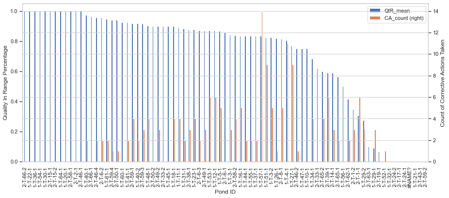

```python
# Plot the Quality in Range percentage by Pond ID, along with the count of corrective actions taken
Plt_df = agg_df[["QIR_mean","CA_count"]]
plt.figure()
ax=Plt_df.plot(kind='bar', secondary_y=['CA_count'], figsize = (15, 6))
ax.set_ylabel('Quality In Range Percentage')
ax.right_ax.set_ylabel('Count of Corrective Actions Taken')
plt.show()
```

### **Observations**: most ponds have quality in range averages above 80%

## Review the distributions of numeric columns for treatment ponds

```python
#"Control" ponds
df_control = df[df["Pond ID"].str.contains("C", na=False)]

#"Treatment" ponds
df_treatment = df[df["Pond ID"].str.contains("T", na=False)]
```

```python
# Specify the primary numerical columns

primary_num_cols = ['Jotform Entry ID', 'Observer ID','DO (mg/L)', 'Temp (C)', 'pH', 'Ammonia (mg/L)', 'Turbidity (cm)',
       'Salinity (ppt)', 'TDS (ppt)', 'Sun','Stocking Density (fish/acre)',
       'Daily feed (kg)', 'Feeding behaviour', 'Air gulping extent', 'Tail splashing extent',
       'Farmer dead fish (15 day count)', 'FWI dead fish count','How many fish did we help?', 'Primary Productivity GPP (mg/L)',
       'Light bottle DO NPP', 'Dark bottle DO R', 'PP (mg/L)',
       'Pond locations visited']
```

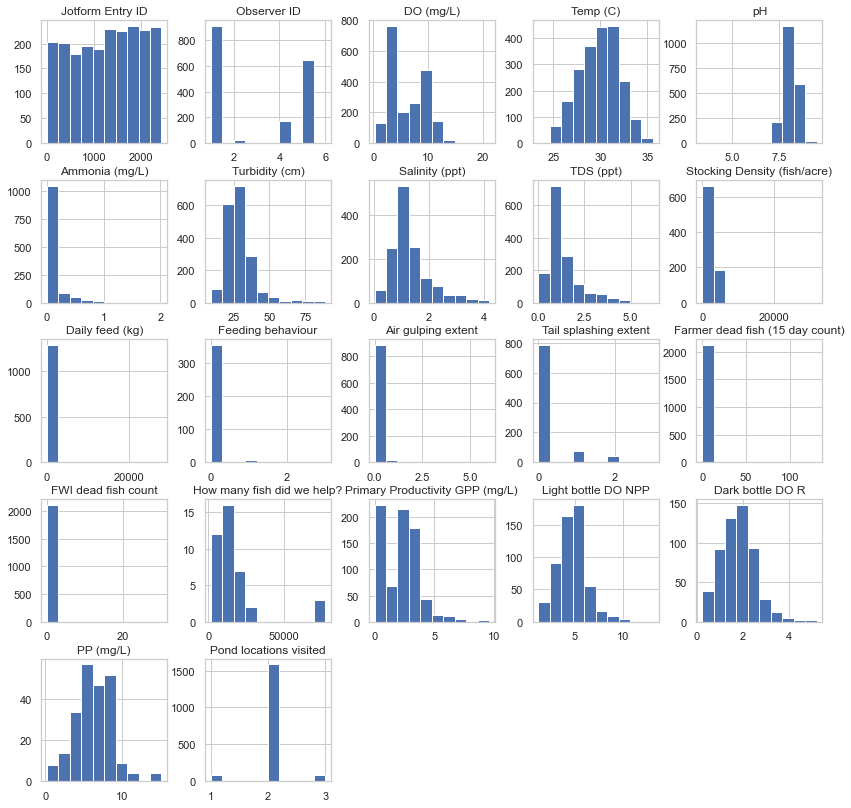

```python
# Creating histograms

df_treatment=df.loc[df['control_pond'] == 0]
df_treatment[primary_num_cols].hist(figsize = (14, 14))

plt.show()
```

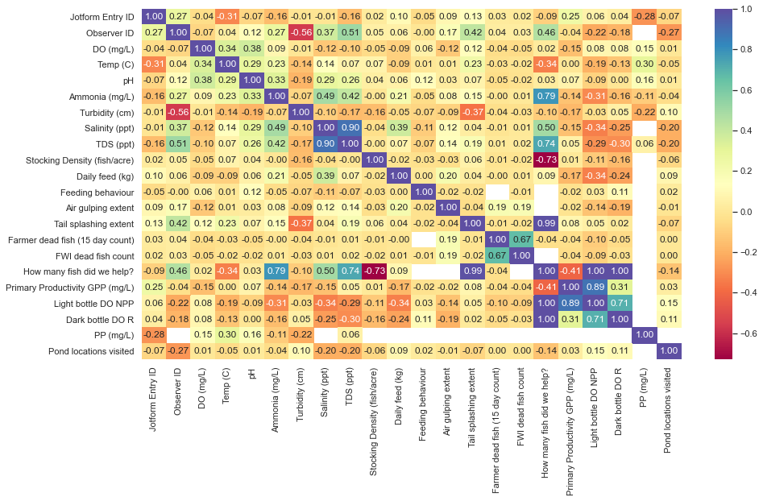

```python
# Plotting the correlation between primary numerical variables
plt.figure(figsize = (15, 8))
df_treatment=df.loc[df['control_pond'] == 0]

sns.heatmap(df_treatment[primary_num_cols].corr(), annot = True, fmt = '0.2f', cmap = "Spectral")
```

## Notes

### Correlations noted:

- Number of fish helped: TDS, Salinity, Ammonia, Tail splashing
- Temp, DO, Ammonia and pH
- Stocking density is negatively correlated with the number of fish helped

# Water Quality Metrics

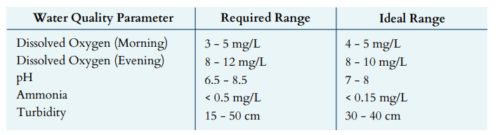

#### source: https://files.fwi.fish/ARA_Commitment.pdf

## Review Dissolved Oxegen

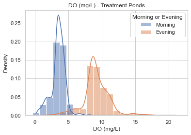

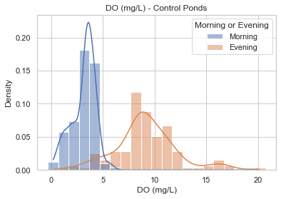

```python
# Create hystograms of water quality parameters

parameter = 'DO (mg/L)' # Options: 'DO (mg/L)', 'Temp (C)', 'pH', 'Ammonia (mg/L)', 'Turbidity (cm)', 'Salinity (ppt)', 'TDS (ppt)', 'Sun', 'Stocking Density (fish/acre)', 'Daily feed (kg)', 'Feeding behaviour', 'Air gulping extent', 'Tail splashing extent', 'Farmer dead fish (15 day count)', 'FWI dead fish count', 'How many fish did we help?', 'Primary Productivity GPP (mg/L)', 'Light bottle DO NPP', 'Dark bottle DO R', 'PP (mg/L)', 'Pond locations visited'
title1 = parameter +' - Treatment Ponds'
title2 = parameter +' - Control Ponds'

sns.histplot(data=df.loc[df['control_pond'] == 0], x=parameter,stat='density', discrete= True, hue="Morning or Evening",hue_order=["Morning", "Evening"], kde=True).set(title=title1)
plt.xticks([0, 5, 10, 15, 20])
plt.show()
sns.histplot(data=df.loc[df['control_pond'] == 1], x=parameter,stat='density',  discrete= True,hue="Morning or Evening",hue_order=["Morning", "Evening"],kde=True).set(title=title2)
plt.xticks([0, 5, 10, 15, 20])
plt.show()
```

### Review dissolved oxygen in morning-only treatment ponds

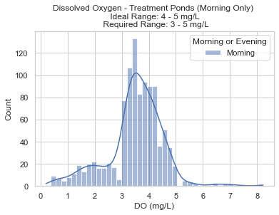

```python
# Set parameters for histogram
parameter = 'DO (mg/L)' # Options: 'DO (mg/L)', 'Temp (C)', 'pH', 'Ammonia (mg/L)', 'Turbidity (cm)', 'Salinity (ppt)', 'TDS (ppt)', 'Sun', 'Stocking Density (fish/acre)', 'Daily feed (kg)', 'Feeding behaviour', 'Air gulping extent', 'Tail splashing extent', 'Farmer dead fish (15 day count)', 'FWI dead fish count', 'How many fish did we help?', 'Primary Productivity GPP (mg/L)', 'Light bottle DO NPP', 'Dark bottle DO R', 'PP (mg/L)', 'Pond locations visited'
Daytime = 'Morning' # Morning or Evening
control = 0 # zero for treatment point, one for control pond
title = 'Dissolved Oxygen - Treatment Ponds (Morning Only) \n Ideal Range: 4 - 5 mg/L \n Required Range: 3 - 5 mg/L'

df_new=df.loc[(df['Morning or Evening'].values == Daytime) & (df['control_pond'] == control)]

sns.histplot(data=df_new, x=parameter,  hue="Morning or Evening",kde=True).set(title=title)
plt.show()
```

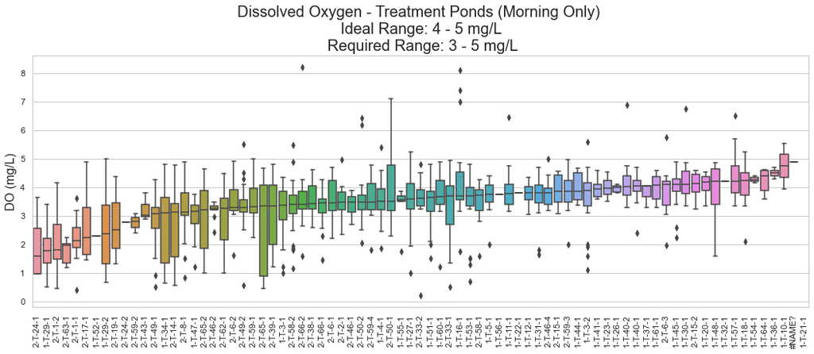

```python
# Create a box plot by Pond ID and water parameter. Specify time of day, and whether it is a treatment or control pond

x = 'Pond ID'
parameter = 'DO (mg/L)' # Options: 'DO (mg/L)', 'Temp (C)', 'pH', 'Ammonia (mg/L)', 'Turbidity (cm)', 'Salinity (ppt)', 'TDS (ppt)', 'Sun', 'Stocking Density (fish/acre)', 'Daily feed (kg)', 'Feeding behaviour', 'Air gulping extent', 'Tail splashing extent', 'Farmer dead fish (15 day count)', 'FWI dead fish count', 'How many fish did we help?', 'Primary Productivity GPP (mg/L)', 'Light bottle DO NPP', 'Dark bottle DO R', 'PP (mg/L)', 'Pond locations visited'
Daytime = 'Morning' # Morning or Evening
control = 0 # zero for treatment point, 1 for control pond
title='Dissolved Oxygen - Treatment Ponds (Morning Only) \n Ideal Range: 4 - 5 mg/L \n Required Range: 3 - 5 mg/L'


df_new=df.loc[(df['Morning or Evening'].values == Daytime) & (df['control_pond'] == 0)]
df_sorted = df_new.groupby(x)[parameter].median().sort_values()

fig = plt.figure(figsize = (18, 6))
sns.boxplot(x = x, y = parameter, data = df_new,order=df_sorted.index)
plt.title(title, fontsize=20)
plt.xlabel(None);
plt.ylabel(parameter, fontsize=16);
plt.xticks(rotation=90);
```

#### Notes on Morning DO levels:

- Ideal Range 4 - 5 mg/L
- Required Range 3 - 5 mg/L
- The histogram shows that the data is bifurcated at 3 mg/L, with a sizable portion of the data below 3 mg/L.
- The morning box plots by pond shows that a number of treatment ponds have low dissolved oxegen.
- Very few ponds are in the ideal range.

### Review dissolved oxygen in evening-only treatment ponds

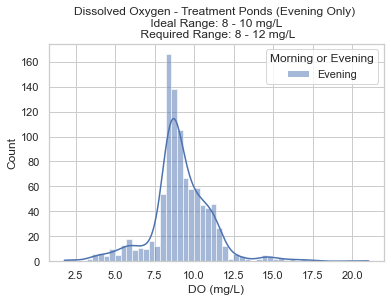

```python
# Set parameters for histogram
parameter = 'DO (mg/L)' # Options: 'DO (mg/L)', 'Temp (C)', 'pH', 'Ammonia (mg/L)', 'Turbidity (cm)', 'Salinity (ppt)', 'TDS (ppt)', 'Sun', 'Stocking Density (fish/acre)', 'Daily feed (kg)', 'Feeding behaviour', 'Air gulping extent', 'Tail splashing extent', 'Farmer dead fish (15 day count)', 'FWI dead fish count', 'How many fish did we help?', 'Primary Productivity GPP (mg/L)', 'Light bottle DO NPP', 'Dark bottle DO R', 'PP (mg/L)', 'Pond locations visited'
Daytime = 'Evening' # Morning or Evening
control = 0 # zero for treatment point, one for control pond
title = 'Dissolved Oxygen - Treatment Ponds (Evening Only) \n Ideal Range: 8 - 10 mg/L \n Required Range: 8 - 12 mg/L'

df_new=df.loc[(df['Morning or Evening'].values == Daytime) & (df['control_pond'] == control)]

sns.histplot(data=df_new, x=parameter,  hue="Morning or Evening",kde=True).set(title=title)
plt.show()
```

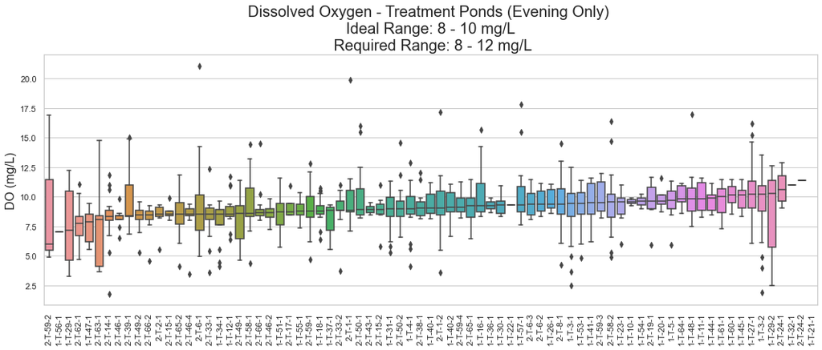

```python
# Create a box plot by Pond ID and water parameter. Specify time of day, and whether it is a treatment or control pond

x = 'Pond ID'
parameter = 'DO (mg/L)' # Options: 'DO (mg/L)', 'Temp (C)', 'pH', 'Ammonia (mg/L)', 'Turbidity (cm)', 'Salinity (ppt)', 'TDS (ppt)', 'Sun', 'Stocking Density (fish/acre)', 'Daily feed (kg)', 'Feeding behaviour', 'Air gulping extent', 'Tail splashing extent', 'Farmer dead fish (15 day count)', 'FWI dead fish count', 'How many fish did we help?', 'Primary Productivity GPP (mg/L)', 'Light bottle DO NPP', 'Dark bottle DO R', 'PP (mg/L)', 'Pond locations visited'
Daytime = 'Evening' # Morning or Evening
control = 0 # zero for treatment point, 1 for control pond
title = 'Dissolved Oxygen - Treatment Ponds (Evening Only) \n Ideal Range: 8 - 10 mg/L \n Required Range: 8 - 12 mg/L'


df_new=df.loc[(df['Morning or Evening'].values == Daytime) & (df['control_pond'] == 0)]
df_sorted = df_new.groupby(x)[parameter].median().sort_values()

fig = plt.figure(figsize = (18, 6))
sns.boxplot(x = x, y = parameter, data = df_new,order=df_sorted.index)
plt.title(title, fontsize=20)
plt.xlabel(None);
plt.ylabel(parameter, fontsize=16);
plt.xticks(rotation=90);
```

## Review pH

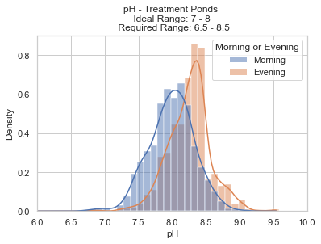

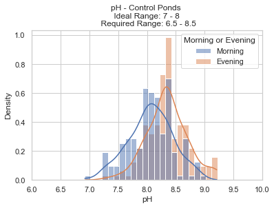

```python
parameter = 'pH' # Options: 'DO (mg/L)', 'Temp (C)', 'pH', 'Ammonia (mg/L)', 'Turbidity (cm)', 'Salinity (ppt)', 'TDS (ppt)', 'Sun', 'Stocking Density (fish/acre)', 'Daily feed (kg)', 'Feeding behaviour', 'Air gulping extent', 'Tail splashing extent', 'Farmer dead fish (15 day count)', 'FWI dead fish count', 'How many fish did we help?', 'Primary Productivity GPP (mg/L)', 'Light bottle DO NPP', 'Dark bottle DO R', 'PP (mg/L)', 'Pond locations visited'
title1 = parameter +' - Treatment Ponds \n Ideal Range: 7 - 8 \n Required Range: 6.5 - 8.5'
title2 = parameter +' - Control Ponds \n Ideal Range: 7 - 8 \n Required Range: 6.5 - 8.5'

sns.histplot(data=df.loc[df['control_pond'] == 0], x=parameter,stat='density', binwidth=0.1 , hue="Morning or Evening",hue_order=["Morning", "Evening"], kde=True).set(title=title1)
plt.xlim([6, 10])
plt.show()
sns.histplot(data=df.loc[df['control_pond'] == 1], x=parameter,stat='density', binwidth=0.1,hue="Morning or Evening",hue_order=["Morning", "Evening"],kde=True).set(title=title2)
plt.xlim([6, 10])
plt.show()
```

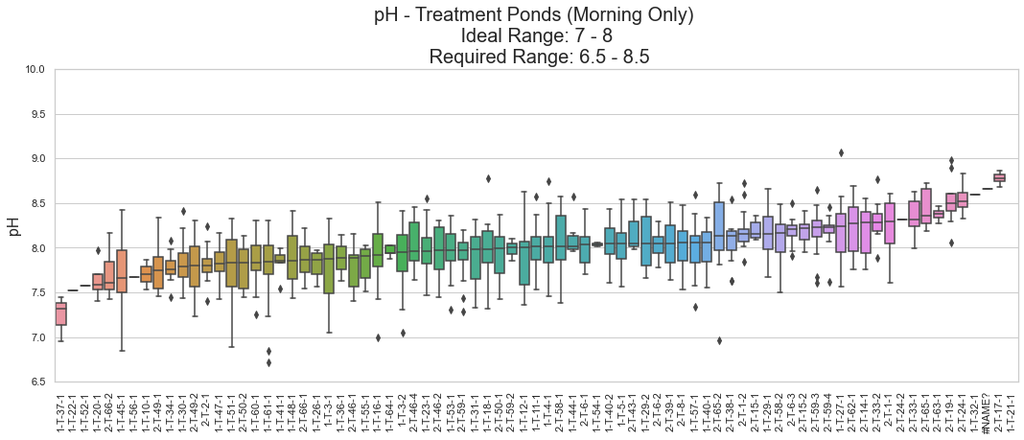

```python
# Create a box plot by Pond ID and water parameter. Specify time of day, and whether it is a treatment or control pond

x = 'Pond ID'
parameter = 'pH' # Options: 'DO (mg/L)', 'Temp (C)', 'pH', 'Ammonia (mg/L)', 'Turbidity (cm)', 'Salinity (ppt)', 'TDS (ppt)', 'Sun', 'Stocking Density (fish/acre)', 'Daily feed (kg)', 'Feeding behaviour', 'Air gulping extent', 'Tail splashing extent', 'Farmer dead fish (15 day count)', 'FWI dead fish count', 'How many fish did we help?', 'Primary Productivity GPP (mg/L)', 'Light bottle DO NPP', 'Dark bottle DO R', 'PP (mg/L)', 'Pond locations visited'
Daytime = 'Morning' # Morning or Evening
control = 0 # zero for treatment point, 1 for control pond
title = 'pH - Treatment Ponds (Morning Only) \n Ideal Range: 7 - 8 \n Required Range: 6.5 - 8.5'


df_new=df.loc[(df['Morning or Evening'].values == Daytime) & (df['control_pond'] == 0)]
df_sorted = df_new.groupby(x)[parameter].median().sort_values()

fig = plt.figure(figsize = (18, 6))
sns.boxplot(x = x, y = parameter, data = df_new,order=df_sorted.index)
plt.title(title, fontsize=20)
plt.xlabel(None);
plt.ylim([6.5, 10])
plt.ylabel(parameter, fontsize=16);
plt.xticks(rotation=90);
```

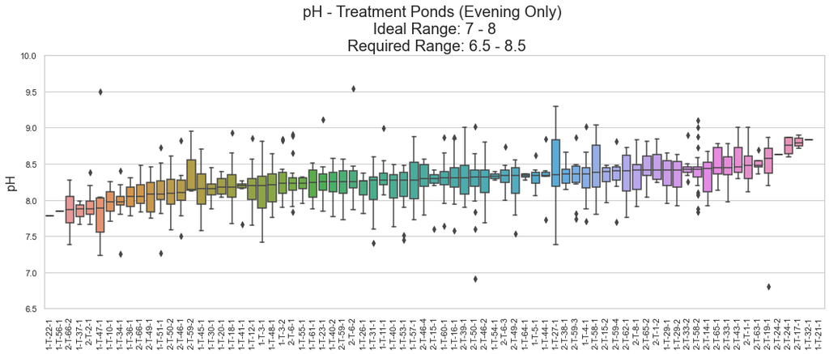

```python
# Create a box plot by Pond ID and water parameter. Specify time of day, and whether it is a treatment or control pond

x = 'Pond ID'
parameter = 'pH' # Options: 'DO (mg/L)', 'Temp (C)', 'pH', 'Ammonia (mg/L)', 'Turbidity (cm)', 'Salinity (ppt)', 'TDS (ppt)', 'Sun', 'Stocking Density (fish/acre)', 'Daily feed (kg)', 'Feeding behaviour', 'Air gulping extent', 'Tail splashing extent', 'Farmer dead fish (15 day count)', 'FWI dead fish count', 'How many fish did we help?', 'Primary Productivity GPP (mg/L)', 'Light bottle DO NPP', 'Dark bottle DO R', 'PP (mg/L)', 'Pond locations visited'
Daytime = 'Evening' # Morning or Evening
control = 0 # zero for treatment point, 1 for control pond
title = 'pH - Treatment Ponds (Evening Only) \n Ideal Range: 7 - 8 \n Required Range: 6.5 - 8.5'


df_new=df.loc[(df['Morning or Evening'].values == Daytime) & (df['control_pond'] == 0)]
df_sorted = df_new.groupby(x)[parameter].median().sort_values()

fig = plt.figure(figsize = (18, 6))
sns.boxplot(x = x, y = parameter, data = df_new,order=df_sorted.index)
plt.title(title, fontsize=20)
plt.xlabel(None);
plt.ylim([6.5, 10])
plt.ylabel(parameter, fontsize=16);
plt.xticks(rotation=90);
```

### Notes on pH:

- Ideal Range 7 - 8
- Required Range 6.5 - 8.5
- Evening pH levels often exceed the ideal upper limit of 8
- Evening pH is significantly higher than mornig

## Review Ammonia

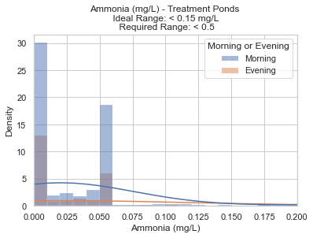

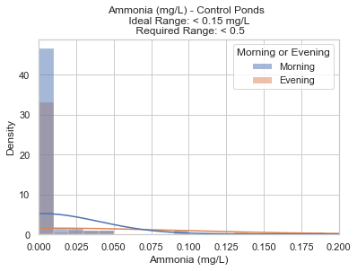

```python
# Create hystograms of water quality parameters

parameter = 'Ammonia (mg/L)' # Options: 'DO (mg/L)', 'Temp (C)', 'pH', 'Ammonia (mg/L)', 'Turbidity (cm)', 'Salinity (ppt)', 'TDS (ppt)', 'Sun', 'Stocking Density (fish/acre)', 'Daily feed (kg)', 'Feeding behaviour', 'Air gulping extent', 'Tail splashing extent', 'Farmer dead fish (15 day count)', 'FWI dead fish count', 'How many fish did we help?', 'Primary Productivity GPP (mg/L)', 'Light bottle DO NPP', 'Dark bottle DO R', 'PP (mg/L)', 'Pond locations visited'
title1 = parameter +' - Treatment Ponds \n Ideal Range: < 0.15 mg/L \n Required Range: < 0.5'
title2 = parameter +' - Control Ponds  \n Ideal Range: < 0.15 mg/L \n Required Range: < 0.5'

sns.histplot(data=df.loc[df['control_pond'] == 0], x=parameter,stat='density', binwidth=0.01 , hue="Morning or Evening",hue_order=["Morning", "Evening"], kde=True).set(title=title1)
plt.xlim([0, 0.2])
plt.show()
sns.histplot(data=df.loc[df['control_pond'] == 1], x=parameter,stat='density', binwidth=0.01 , hue="Morning or Evening",hue_order=["Morning", "Evening"],kde=True).set(title=title2)
plt.xlim([0, 0.2])
plt.show()
```

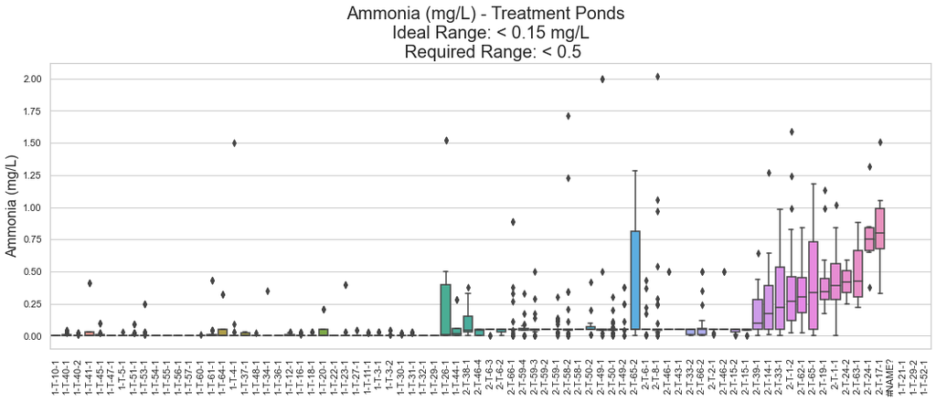

```python
# Create a box plot by Pond ID and water parameter. Specify time of day, and whether it is a treatment or control pond

x = 'Pond ID'
parameter = 'Ammonia (mg/L)' # Options: 'DO (mg/L)', 'Temp (C)', 'pH', 'Ammonia (mg/L)', 'Turbidity (cm)', 'Salinity (ppt)', 'TDS (ppt)', 'Sun', 'Stocking Density (fish/acre)', 'Daily feed (kg)', 'Feeding behaviour', 'Air gulping extent', 'Tail splashing extent', 'Farmer dead fish (15 day count)', 'FWI dead fish count', 'How many fish did we help?', 'Primary Productivity GPP (mg/L)', 'Light bottle DO NPP', 'Dark bottle DO R', 'PP (mg/L)', 'Pond locations visited'
control = 0 # zero for treatment point, 1 for control pond
title = parameter + ' - Treatment Ponds  \n Ideal Range: < 0.15 mg/L \n Required Range: < 0.5'


df_new=df.loc[(df['control_pond'] == 0)]
df_sorted = df_new.groupby(x)[parameter].median().sort_values()

fig = plt.figure(figsize = (18, 6))
sns.boxplot(x = x, y = parameter, data = df_new,order=df_sorted.index)
plt.title(title, fontsize=20)
plt.xlabel(None);
#plt.ylim([6.5, 10])
plt.ylabel(parameter, fontsize=16);
plt.xticks(rotation=90);
```

### Notes on Amonia:

- Ideal Range < 0.15
- Required Range < 0.5
- Most ponds have median values within the ideal.
- The OOR values seem to be concentrated in about a dozen ponds.

## Review Turbidity

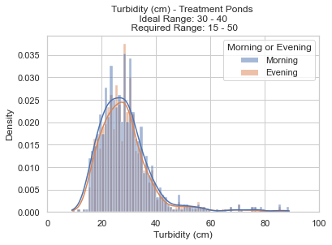

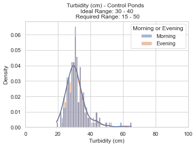

```python
# Create hystograms of water quality parameters

parameter = 'Turbidity (cm)' # Options: 'DO (mg/L)', 'Temp (C)', 'pH', 'Ammonia (mg/L)', 'Turbidity (cm)', 'Salinity (ppt)', 'TDS (ppt)', 'Sun', 'Stocking Density (fish/acre)', 'Daily feed (kg)', 'Feeding behaviour', 'Air gulping extent', 'Tail splashing extent', 'Farmer dead fish (15 day count)', 'FWI dead fish count', 'How many fish did we help?', 'Primary Productivity GPP (mg/L)', 'Light bottle DO NPP', 'Dark bottle DO R', 'PP (mg/L)', 'Pond locations visited'
title1 = parameter +' - Treatment Ponds \n Ideal Range: 30 - 40 \n Required Range: 15 - 50'
title2 = parameter +' - Control Ponds  \n Ideal Range: 30 - 40 \n Required Range: 15 - 50'

sns.histplot(data=df.loc[df['control_pond'] == 0], x=parameter,stat='density', binwidth=1 , hue="Morning or Evening",hue_order=["Morning", "Evening"], kde=True).set(title=title1)
plt.xlim([0, 100])
plt.show()
sns.histplot(data=df.loc[df['control_pond'] == 1], x=parameter,stat='density', binwidth=1 , hue="Morning or Evening",hue_order=["Morning", "Evening"],kde=True).set(title=title2)
plt.xlim([0, 100])
plt.show()
```

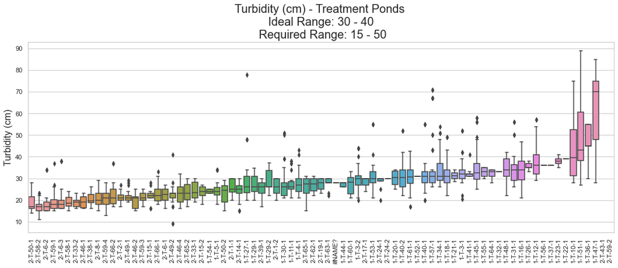

```python
# Create a box plot by Pond ID and water parameter. Specify time of day, and whether it is a treatment or control pond
x = 'Pond ID'
parameter = 'Turbidity (cm)' # Options: 'DO (mg/L)', 'Temp (C)', 'pH', 'Ammonia (mg/L)', 'Turbidity (cm)', 'Salinity (ppt)', 'TDS (ppt)', 'Sun', 'Stocking Density (fish/acre)', 'Daily feed (kg)', 'Feeding behaviour', 'Air gulping extent', 'Tail splashing extent', 'Farmer dead fish (15 day count)', 'FWI dead fish count', 'How many fish did we help?', 'Primary Productivity GPP (mg/L)', 'Light bottle DO NPP', 'Dark bottle DO R', 'PP (mg/L)', 'Pond locations visited'
control = 0 # zero for treatment point, 1 for control pond
title = parameter +' - Treatment Ponds \n Ideal Range: 30 - 40 \n Required Range: 15 - 50'

df_new=df.loc[(df['control_pond'] == 0)]
df_sorted = df_new.groupby(x)[parameter].median().sort_values()

fig = plt.figure(figsize = (18, 6))
sns.boxplot(x = x, y = parameter, data = df_new,order=df_sorted.index)
plt.title(title, fontsize=20)
plt.xlabel(None);
#plt.ylim([6.5, 10])
plt.ylabel(parameter, fontsize=16);
plt.xticks(rotation=90);
```

### Notes on Turbidity:

- Ideal Range 30 - 40 cm
- Required Range 15 - 50 cm
- Measurement time of day does not have a bearing on turbidity.
- Control ponds show similar turbidity levels.
- Most ponds do not fall within the ideal range but they do fall within the required range.
- A few ponds are outliers on the high end, i.e., > 40 cm.

## Next steps: Investigate the impact of actions taken

### Actions taken:

- Quality in range? : Is water quality in the required range? : Yes, No
- Parameter(s) OOR : Which parameter(s) is/are out of range? : Descriptive
- CA Requested : Farmer : Corrective actions requested from the farmer : Descriptive
- CA Taken? : Farmer : Did the farmer implement the corrective actions? : Yes, No
- Correct CA Taken? : Farmer : Did the farmer implement the corrective actions for achieving ideal ranges? : Yes, No
- CA Actual : Farmer : Corrective actions taken by the farmer : Descriptive
- CA Difficulty : Farmer : How did the farmer find implementing the corrective actions? : Descriptive
- Post CA improvement? : Did the targeted water quality parameters improve to the required range after the implementation of - - - corrective actions? : Yes, No